# Data Visualization Homework Assignment 3

Student’s Name: Chutian Zhou UNI: cz2482

April 2, 2018

In this write-up, I will include code chunks[^1], results as well as my short inpretations.

## 0. Housekeeping Stuff

```r
#Read essential packages
library(dplyr)
library(ggplot2)
library(tm)
library(qdap)
library(parallel)
library(pbapply)
library(tidytext)
library(wordcloud)
library(quanteda)
library(plotrix)
library(magrittr)
library(tidyverse)
```

## 1: Identifying Successful Projects

### a) Success by Category

I define success as achievement ratio, which is calculated by dividing the actual fund the project receives (*pledged*) by the original target amount (*target*).

To visualize “attractiveness” of each category, I group all observations by top categories (*top_category* in the `kickstarter` data frame) they belong to (theater, technology, publishing, etc.) first. After this step, the average achievement ratio of all projects in a certain category is calculated. The final step is simply correlating *top_category* with *mean* (i.e. average achievement ratio) in the `ggplot` function.

The code chunk below returns the plot.

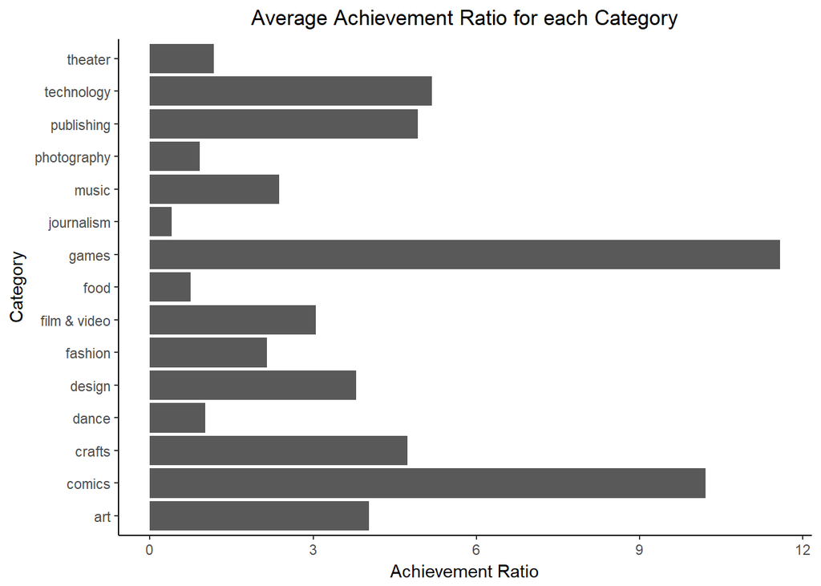

```r
#read file
kickstarter<-read.csv("kickstarter_projects.csv",header=TRUE,sep=",")
kickstarter<-select(kickstarter,-source_url)%>%unique()

#generate achievement_ratio
kickstarter$achievement_ratio<-kickstarter$pledged/kickstarter$goal

#remove Inf
kickstarter2<-kickstarter[kickstarter$achievement_ratio!=Inf,]

#calculate mean achievement_ratio for each top category
ks<-kickstarter2%>%group_by(top_category)%>%summarise(mean=mean(achievement_ratio))

#remove the 16th row (NA)
ks<-ks[-16,]

#draw plot
ggplot(ks,aes(top_category,mean))+
  stat_summary(fun.y=mean,geom="bar")+coord_flip()+
  theme_classic()+
  scale_y_continuous(name="Achievement Ratio")+
  scale_x_discrete(name="Category")+
  ggtitle("Average Achievement Ratio for each Category")+
  theme(plot.title = element_text(hjust =0.5))+coord_flip()
```

The figure above shows that projects relative to games are most successful in attracting funding. The average achievement ratio of this category is close to 12. The second and the third successful categories are comics and technology in terms of the mean value of the achievement ratio.

## 2: Writing your Success Story

### a) Cleaning the Text and Word Cloud

My sample of 1000 most successful projects are those have the largest achievement ratios. To extract such sample, I arrang all observations in the `kickstarter` data frame in a descending order in terms of their achievement ratios, subset the first 1000 of them and store them in the `success` data frame.[^2]

I have also created the `unsuccess` data frame in a similar manner for the preparation of tackling Question 2(b).

The critical step is using the `DataframeSource` and `VCorpus` functions to transform the `success` data frame to a corpus. In addition, I have used the `removeNumPunct` and `stemCompletion2` functions introduced by Professor in his lecture to clean and stem[^3] the `success` corpus. After all these steps, I make a matrix, calculate word frequencies and draw a wordcloud of the most frequent words among the most successful 1000 projects based on term frequency.

The code chunk below returns the wordcloud.

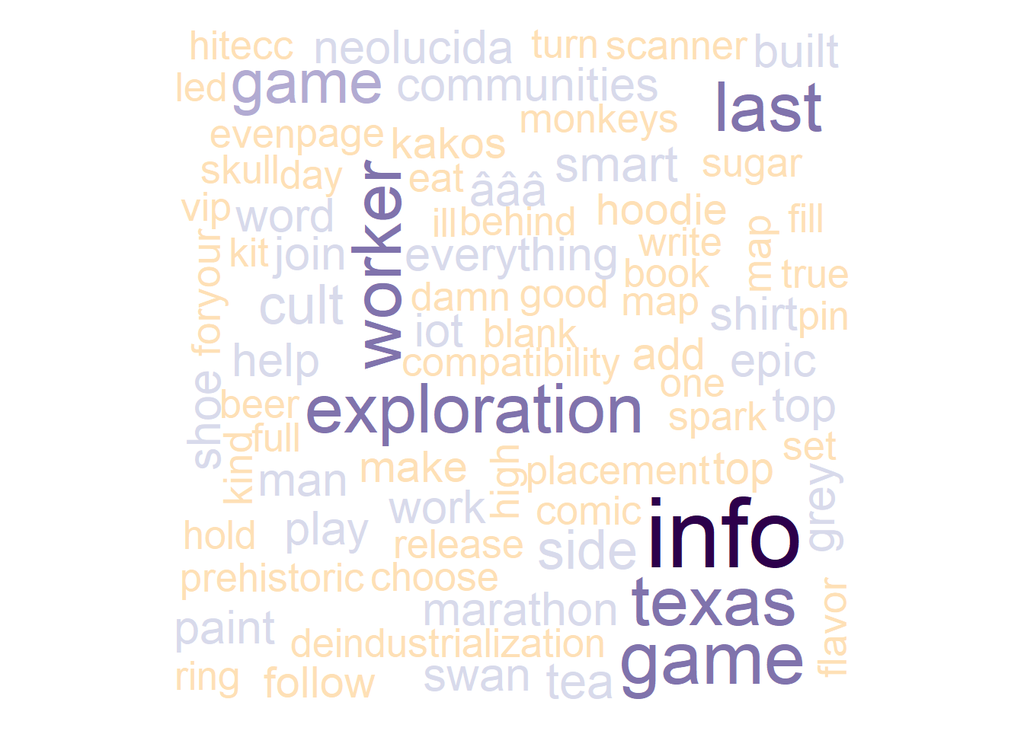

```r
#1000 most successful
success<-kickstarter%>%arrange(desc(achievement_ratio))
success<-success[c(1:1000),c(2,9)]

colnames(success)[1]<-"text"
colnames(success)[2]<-"doc_id"

success$text<-as.character(success$text)
success$doc_id<-as.numeric(success$doc_id)

#1000 most unsucessful
unsuccess<-kickstarter%>%arrange(achievement_ratio)
unsuccess<-unsuccess[c(1:1000),c(2,9)]

colnames(unsuccess)[1]<-"text"
colnames(unsuccess)[2]<-"doc_id"

unsuccess$text<-as.character(unsuccess$text)
unsuccess$doc_id<-as.numeric(unsuccess$doc_id)

suc_source<-DataframeSource(success)
suc_corpus<-VCorpus(suc_source)

#cleaning function
removeNumPunct<-function(x){gsub("[^[:alpha:][:space:]]*", "", x)}
clean_corpus<-function(corpus){
  corpus<-tm_map(corpus, removePunctuation)
  corpus<-tm_map(corpus, content_transformer(tolower))
  corpus<-tm_map(corpus, content_transformer(replace_symbol))
  corpus<-tm_map(corpus, removeWords, c(stopwords("en")))
  corpus<-tm_map(corpus, removeNumbers)
  corpus<-tm_map(corpus, content_transformer(removeNumPunct))
  corpus<-tm_map(corpus, stripWhitespace)
  return(corpus)
}

#use clean_corpus function to clean suc_corpus
suc_corpus_clean<-clean_corpus(suc_corpus)

#stemming suc_corpus_clean
suc_stemmed<-tm_map(suc_corpus_clean,stemDocument)

#stemcompletion
stemCompletion2<-function(x,dictionary) {
  x<-unlist(strsplit(as.character(x), " "))
  x<-x[x != ""]
  x<-stemCompletion(x, dictionary=dictionary)
  x<-paste(x, sep="", collapse=" ")
  PlainTextDocument(stripWhitespace(x))
}

#complete suc_stemmed
suc_comp_all<-mclapply(suc_stemmed,stemCompletion2,
                     dictionary=suc_corpus_clean)

success[]<-lapply(success,as.character)

for (i in 1:dim(success)[1]){
  suc_comp_all[[i]]$meta$id<-success[i,"doc_id"]
}

suc_comp_all<-as.VCorpus(suc_comp_all)

#make a dtm
suc_dtm<-DocumentTermMatrix(suc_comp_all)

#convert suc_dtm to a matrix
suc_m<-as.matrix(suc_dtm)

#tidying suc_dtm
suc_td<-tidy(suc_dtm)

#calculating frequencies
suc_tf_idf<-suc_td%>%
  bind_tf_idf(term,document,count)%>%
  arrange(desc(tf))

#draw wordcloud
purple_orange<-brewer.pal(10,"PuOr")
purple_orange<-purple_orange[-(1:2)]
set.seed(1)
wordcloud(suc_tf_idf$term,suc_tf_idf$tf,
          max.words=500,colors=purple_orange)
```

### b) Success in Words

The first step is merging `success` and `unsuccess`. I use the `rbind` function here. I name the outcome data frame as `total`.

```r
#merge success and unsuccess
total<-rbind(success,unsuccess)

total_source<-DataframeSource(total)
total_corpus<-VCorpus(total_source)

#-------these are cleaning and stemming steps--------
#clean total_corpus
total_corpus_clean<-clean_corpus(total_corpus)

#stem total_corpus_clean
total_stemmed<-tm_map(total_corpus_clean,stemDocument)

#complete total_stemmed
total_comp_all<-mclapply(total_stemmed,stemCompletion2,
                       dictionary=total_corpus_clean)

total[]<-lapply(total, as.character)

for (i in 1:dim(total)[1]){
  total_comp_all[[i]]$meta$id<-total[i,"doc_id"]
}

total_comp_all<-as.VCorpus(total_comp_all)
#-----------------------------------------------------
```

The tricky yet critical step in this question, from my perspective, is converting `total_m` (a matrix converted from a term-document matrix) to `total_df` (a data frame). This is for the convenience of calculating raw count of each specific word in 1000 most successful projects and their counterparts.

```r
#make a tdm
total_tdm<-TermDocumentMatrix(total_comp_all)

#convert tdm to a matrix
total_m<-as.matrix(total_tdm)

#convert matrix to a df
total_df<-as.data.frame(total_m)
```

To have an impression of `tota_df`, see the chunk below for the dimension as well as the first three columns and rows of this data frame.

```r
#dimension of total_df
dim(total_df)
```

```
## [1] 4927 2000
```

```r
#the first three columns and rows of total_df
total_df[1:3,1:3]
```

```
##               1388400809 521903377 550443638
## âââ                    0         0         0
## ãããã                   0         0         0
## ãããããåäããããïÿ          0         0         0
```

In `total_df`, the labels of the first 1000 columns are IDs of 1000 most successful projects, and the labels from column 1001 to column 2000 are IDs of 1000 least successful ones. *suc_sum*, the frequency of each specific word in all successful projects, is calculated through the `rowSums` function. Similarly, *unsuc_sum* is a column containing the word count of all words for all unsuccessful projects.

```r
#generate suc_sum, which is the sum of word counts, as well as unsuc_sum
total_df$suc_sum<-rowSums(total_df[,1:1000])
total_df$unsuc_sum<-rowSums(total_df[,1001:2000])
```

Finally, the chunk below generates the pyramid plot as the question aks. The plot shows the frequency differences of top 20 words between successful and unsuccessful projects.

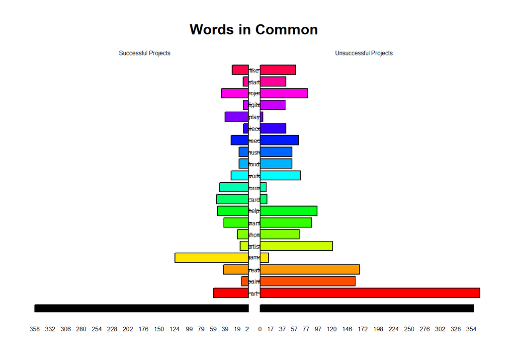

```
## [1] 5.1 4.1 4.1 2.1
```

```r
#draw plot
common_words<-subset(total_df,total_df[,2001]>0&total_df[,2002]>0)
difference<-abs(common_words[,2001]-common_words[,2002])
common_words<-cbind(common_words, difference)
common_words<-common_words[,2001:2003]
common_words<-common_words[order(common_words[, 3],decreasing=TRUE),]
top20_df<-data.frame(x=common_words[1:20,1],
                     y=common_words[1:20,2],
                     labels=rownames(common_words[1:20, ]))
pyramid.plot(top20_df$x,top20_df$y,labels=top20_df$labels,
                  gap=10,top.labels=c("Successful Projects", " ", "Unsuccessful Projects"),
                  main="Words in Common",laxlab = NULL,
                  raxlab=NULL,unit=NULL,labelcex=0.5)
```

### c) Simplicity as a virtue

To have more variations, I focus on the original `kickstarter` data frame instead of `total`.

Overall speaking, this question is simple and intuitive. The readability measure, Flesh Kincaid, is calculated via the `textstat_readability` function.

I have a drawn a scatter plot correlating the readability measure with the achievement ratio. The smoother shows that the achievement ratio remains constant at a very low value (approximately 0) no matter how the Flesch-Kincaid Grade Level changes. We cannot argue that there is a positive correlation between variable *Flesch.Kincaid* and variable *achievement_ratio*, as some people might contend.

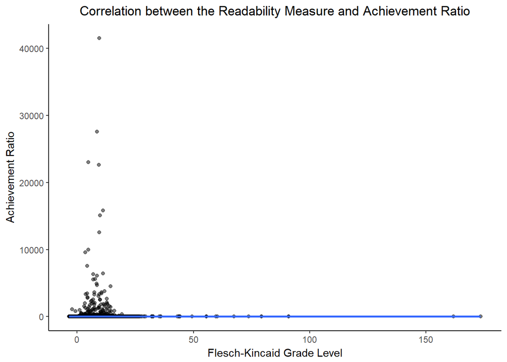

```r
kickstarter$blurb<-as.character(kickstarter$blurb)
fk<-textstat_readability(kickstarter$blurb,
                                  measure=c('Flesch.Kincaid'))

#there is a mismatch...
fk$document<-as.numeric(gsub("text", "", fk$document))
kickstarter$document<-1:nrow(kickstarter)
kickstarter<-kickstarter%>%left_join(fk)

#draw plot
ggplot(kickstarter,aes(Flesch.Kincaid,achievement_ratio))+geom_point(alpha=0.5)+
  geom_smooth()+theme_classic()+
  xlab("Flesch-Kincaid Grade Level")+
  ylab("Achievement Ratio")+
  ggtitle("Correlation between the Readability Measure and Achievement Ratio")+
  theme(plot.title=element_text(hjust=0.5))
```

## 3. Sentiment

### a) Stay Positive

In this question, I first generate a data frame called `total2`. It includes 1979 most and least successful projects (I have deleted duplicates), and has three variables: *text* (i.e. blurbs in the `kickstarter` data frame), *doc_id* and *achievement_ratio*. I retain *achievement_ratio* in `total2` because I will draw a scatter plot later correlating the polarity score with the achievement ratio.

The tone, or in other words, the polarity score for each text, is generated by using the `polarity` function contained in the `qdap` package. The outcome result is a list-like “large polarity”, so the next step is to extract useful information (i.e. *doc_id* and *polarity*) from it and put them in a new data frame (I name it `sentiment2`).

```r
#create subset, which has id and a_r
subset<-kickstarter[,c(9,23)]

#change "id" to "doc_id"
colnames(subset)[1]<-"doc_id"

#change the format of doc_id in total
total$doc_id<-as.integer(total$doc_id)

#merge total and subset. Now we have text, doc_id and a_r
total2<-total%>%left_join(subset)

#remove duplicates
total2<-total2[!duplicated(total2$text),]

#get polarity score
sentiment<-total2%$%polarity(total2$text,doc_id)

#it's a "Large polarity". Now convert it into a data frame
sentiment2<-data.frame(doc_id=sentiment$all$doc_id,polarity=sentiment$all$polarity)
```

Lastly, I combine `sentiment2` and `total2` together so that the outcome data frame `total3` has four essential variables: *text*, *doc_id*, *achievement_ratio* and *polarity* (see the chunk below for the first five rows). The scatter plot thus can be drawn.

```r
#merge total2 and sentiment2. Now we have a_r as well as polarity score
total3<-total2%>%left_join(sentiment2)

total3[c(1:5),c(1:4)]
```

```
##                                                                                                                                      text
## 1                 Energy Hook is a grapple-and-swing-and-run-on-walls-for-style game by Jamie Fristrom, creator of the Spider-Man 2 game.
## 2                   Meticulously crafted wooden clock sculptures that shift the way you feel time's passage. Made in Kalamazoo, Michigan.
## 3                  Every PAX, people ask "When are you doing more Podcasts?!?!" With your help, the answer will be "Really, Really Soon."
## 4    Award-Winning Audio Design Experts Voix are back with their latest product. The amazing mi8| Retro Duo Wireless Stereo Sound System.
## 5 A card game embracing everything one could hate about games, gaming & gamers created to be silly but turned out to be a fun little game
##       doc_id achievement_ratio   polarity
## 1 1388400809          41535.01  0.0000000
## 2  521903377          27588.23  0.2425356
## 3  550443638          23036.07  0.0000000
## 4 1077219132          22603.00  0.2182179
## 5 1649223922          15804.00 -0.3600000
```

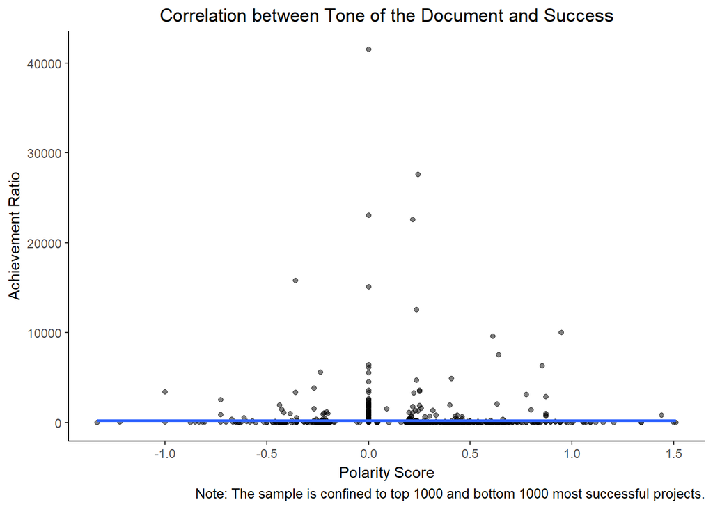

```r
#draw plot
ggplot(total3,aes(polarity,achievement_ratio))+geom_point(alpha=0.5)+
  geom_smooth()+
  theme_classic()+ylab("Achievement Ratio")+xlab("Polarity Score")+
  ggtitle("Correlation between Tone of the Document and Success")+
  theme(plot.title = element_text(hjust = 0.5))+
  labs(caption="Note: The sample is confined to top 1000 and bottom 1000 most successful projects.")
```

Again, there is no obvious correlation between polarity score and achievement ratio; the latter is not affected by the independent variable *polarity*, at least according to the figure above. It seems that the tone of the short description of a project does not have impacts on its success. This makes sense; usually the exact entity rather than the description of a project determines its success.

### b) Positive vs Negative

First of all, I remove all observations in `total3` that have zeros in polarity score.[^4] Then, I generate a categorical variable *set* that is “positive” if the polarity score is greater than 0, and “negative” if the polarity is smaller than 0.

The next step is consequential: applying the `aggregate` function to the data frame `total4` which has two variables *text* and *set* to have two large sets of documents (i.e. positive and negative).

The following steps are just repeating what I have done in Question 2(a): converting the data frame to a corpus, cleaning it using the `clean_corpus` function introduced by Professor, converting the clean corpus to a term-document matrix and ultimately a matrix.[^5]

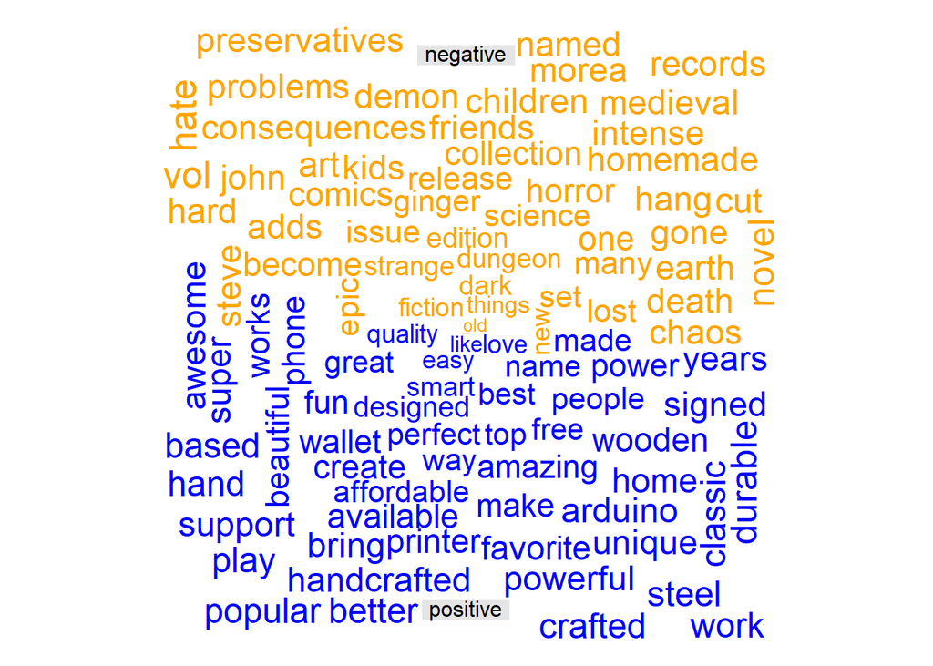

```r
#remove all obs that have 0s in polarity score
total4<-total3[apply(total3[c(2:4)],1,function(z)!any(z==0)),]

#generate positive/negative
total4$set<-ifelse(total4$polarity>0,"positive","negative")

#subset total4 so that we only have text and set
total4<-total4[,c(1,5)]

#aggregate texts based on positive/negative
total4<-aggregate(total4$text, list(total4$set), paste, collapse="")

colnames(total4)[1]<-"doc_id"
colnames(total4)[2]<-"text"
total4$doc_id<-as.factor(total4$doc_id)

total4_source<-DataframeSource(total4)
total4_corpus<-VCorpus(total4_source)

#clean total4_corpus
total4_corpus_clean<-clean_corpus(total4_corpus)

#create a term_document matrix
total4_tdm<-TermDocumentMatrix(total4_corpus_clean)

#convert tdm to a matrix
total4_m<-as.matrix(total4_tdm)

comparison.cloud(total4_m, colors = c("orange", "blue"),
                 scale=c(0.1,2), title.size= 1,
                 max.words=150)
```

The graph above is the comparison cloud showing the most frequent positive and negative words in the sample of top and bottom 1000 successful projects.

### c) Get in Their Mind

I think this question is ambiguous in what exactly it wants me to do, so I will provide my personal answer here.

I intuition is drawing a scatter plot correlating the NRC score and the achievement ratio (pretty much like the one in 3(a)). The variable *score_nrc* (*nrc_positive*-*nrc_negative*) is what I generate for the preparation of the figure. My reasoning is that all words essentially can be categorized into two groups: positive and negative. For instance, “anger”, “disgust”, “fear”, “sadness” all belong to negative words, whereas “joy” and “trust” are both subsets of positive words. So why not have a general NRC score that accounts for all these emotions?[^6]

The chunk below shows how I extract words from original texts in `total2`, clean the `total2_tidy` data frame and calculate the NRC score.

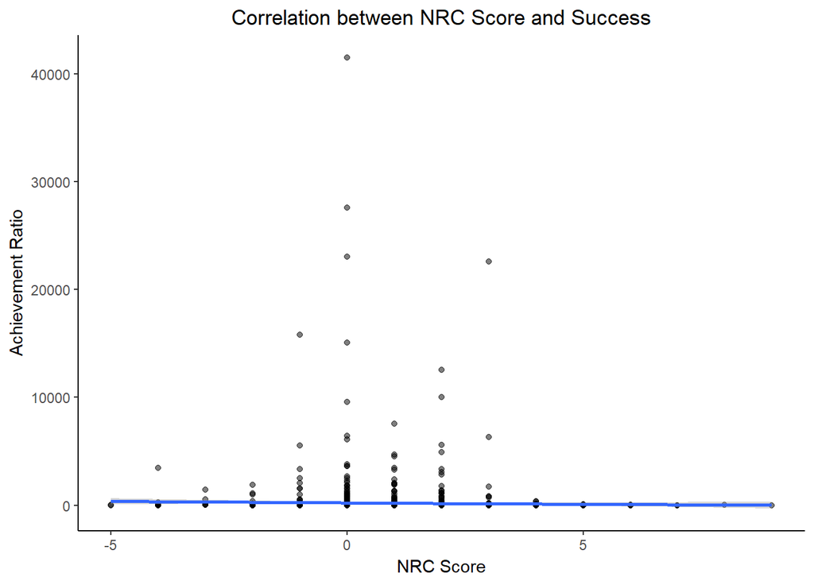

```r
total2_clean<-total2 %>%
  mutate(h_number=row_number())

total2_tidy<-total2_clean%>%
  unnest_tokens(word,text)

total2_tidy<-total2_tidy %>%
  anti_join(stop_words)

sentiment_nrc<-total2_tidy %>%
  inner_join(get_sentiments("nrc")) %>%
  count(h_number, sentiment) %>%
  spread(sentiment, n, fill=0) %>%
  setNames(c(names(.)[1],paste0('nrc_', names(.)[-1]))) %>%
  mutate(score_nrc=nrc_positive-nrc_negative) %>%
  ungroup()

total2_full<-full_join(total2_clean,sentiment_nrc)%>%
  mutate_each(funs(replace(.,which(is.na(.)),0)),starts_with("score"),starts_with("nrc"))

ggplot(total2_full,aes(score_nrc,achievement_ratio))+geom_point(alpha=0.5)+
  xlab("NRC Score")+ylab("Achievement Ratio")+theme_classic()+
  ggtitle("Correlation between NRC Score and Success")+
  theme(plot.title = element_text(hjust = 0.5))+geom_smooth()
```

Again, the figure shows that the NRC score, calculated by minusing negative word count from positive word count, has no obvious effect on the achievement ratio. In essence, based on Question 3(a), (b) and (c), we are pretty confident to draw the conclusion that the tone of the blurb is not an efficient predictor of the success of a project.

[^1]: I know they are not required, but I put them in the `html` file anyway for TAs’ better reference.
[^2]: See the first two lines of the chunk below.
[^3]: And complete the stems, of course.
[^4]: Because I regard polarity score>0 as positive, while polarity score<0 as negative. For the texts that have polarity scores equal to 0, they are sort of “neutral” and should not be considered.
[^5]: I think there is a problem in the instruction of Question 3(b). To draw a comparison cloud, we should have a term-document matrix, not a document-term matrix as Professor has asked.
[^6]: Of course, I have generated word count under each emotion.